# Final Report

2023-05-20

## Introduction

In this project, we look at the spread of COVID-19 in the United States in the first wave. We explore the Data using PCA and report our exploratory findings. We recall that the response to the pandemic was fragmented, even in the initial stages of the pandemic, wherein all states had slightly different degrees of stay at home, face covering and travel restrictions which were implemented at different points of time. Thus, we restrict ourselves to exploratory data analysis on this data-set.

The data we have is regarding the cumulative number of deaths cases in USA by county from [USAfacts](https://static.usafacts.org/public/data/covid-19/covid_deaths_usafacts.csv) . We decided to group it by state and to threshold at 2 Deaths in each state to declare the start of the pandemic. Then, we look at the next 60 days and study the evolution of the pandemic dynamics for per capita death.

However, we recognise that an increase of 5 deaths at the beginning of the wave may not have the same relative impact as 5 deaths towards the end of the wave. To ensure a more comparable scale for the data, we apply a logarithmic transformation to these cumulative numbers. We apply the PCA on this data to gather insights about the progression of the pandemic.

## Exploration of the Data

First, we plot the cumulative per capita deaths to see the evolution of the pandemic in Figure 1. We see that the start of the pandemic is very similar, with almost all states being tightly together until the first 20 days when they start to diverge. The highest curves are Michigan, New York and New Jersey.

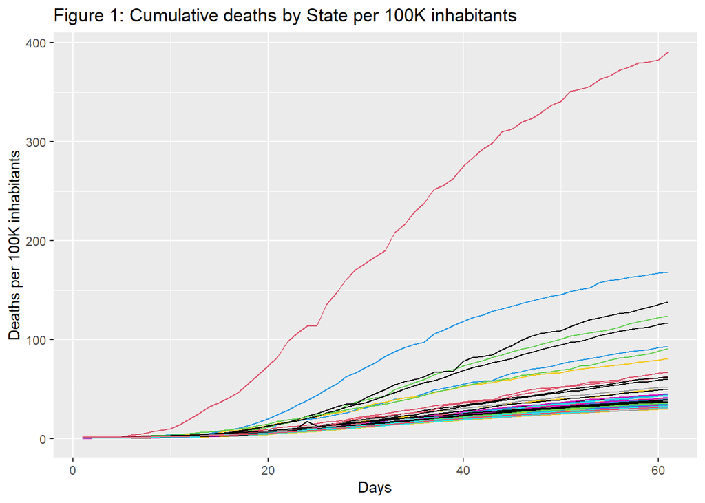

Now, we look at the plots of the Principal Components. In Figure 2, we see that the first principal component is in line with our observation that the beginning of the pandemic is very similar for all the states. We see that that the First principal component discounts the first 20-25 days and emphasizes the later month on the first wave. We also remark that this component explains 82% of the variance in the data.

## Results of PCA

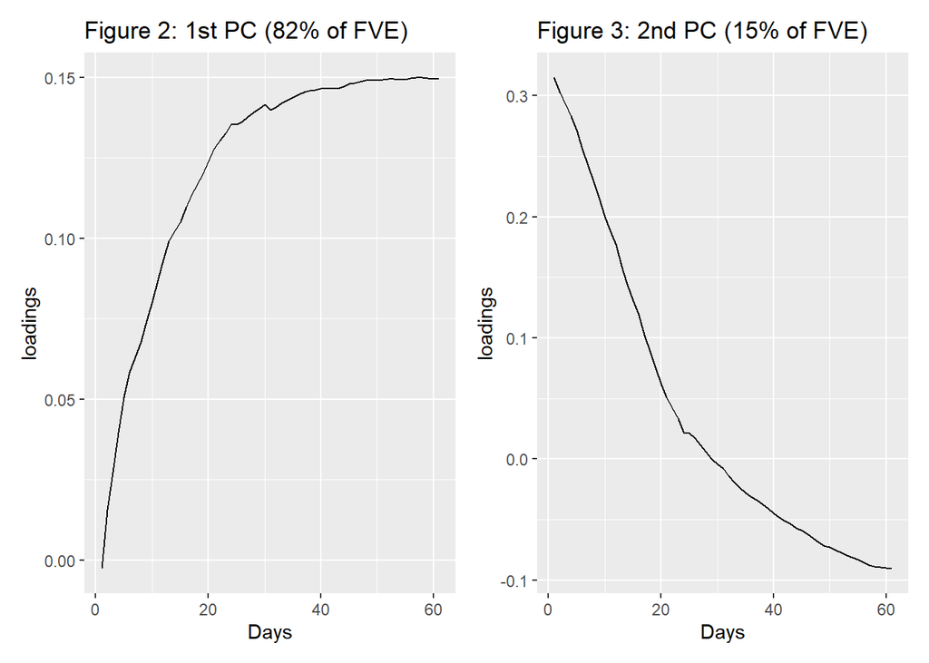

Lastly, we remark that the first two principal components explain 97% of the variability in the data and we choose to ignore the other components. The plot of PC1 vs PC2 was very tightly clustered and we choose to not present it because it was uninformative.

## Conclusion

We see that the variability in the first wave of the COVID-19 pandemic is explained adequately by the first and second principal components. In our opinion, this is because of the different environments and measures taken in each state. There is very less variability in the first few weeks as the transmission has not increased to high levels. In the last month of the first wave, we see a lot of variability in the evolution of the pandemic.